# Econ 631 Final Presentation

5/12/2022

```
## [1] "sf"         "data.frame"
```

## The Yegon Think-Tank

- My Role: Junior Data Analyst Intern
- The Question:

What are the boundaries for Migration in Northern Africa?

## Populations Decimated:

- Changes in Homeland:

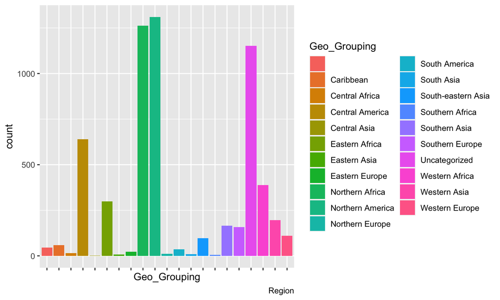

## Very Large Amounts of people lost along the way.

- Each point represents an incident, the amount lost are the total.

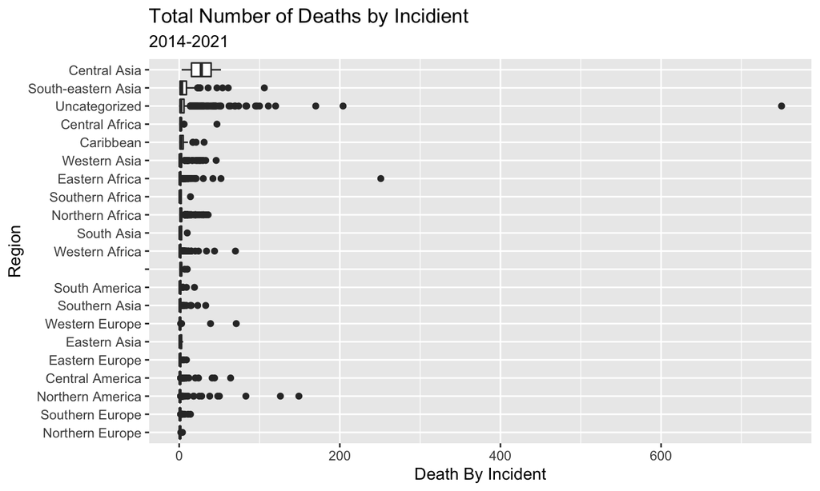

## Picture is worth a 1000 Words

- Mapping the Data

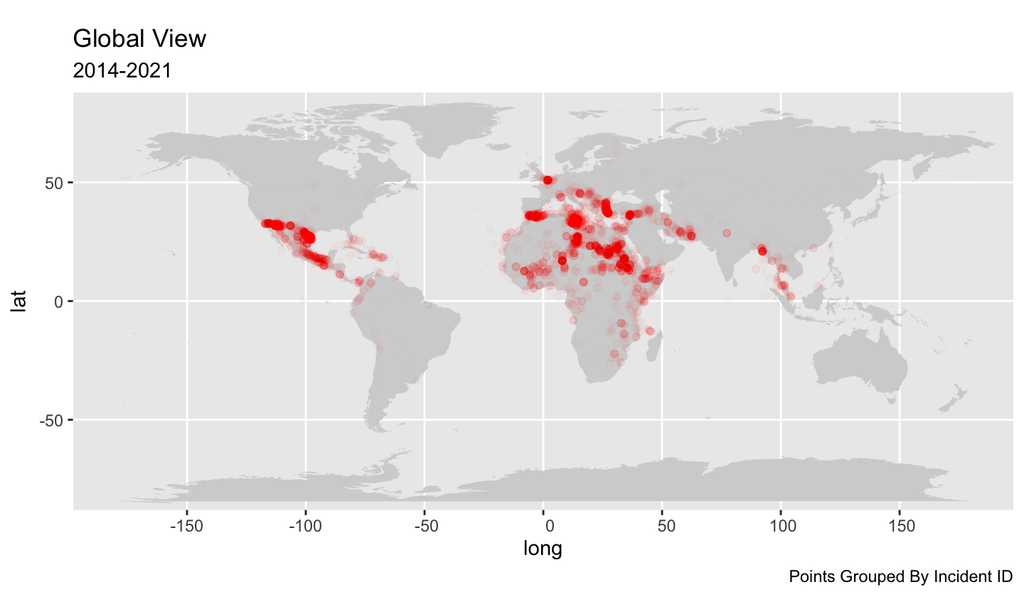

## Looking to Africa:

- There seem to be some visual patters:

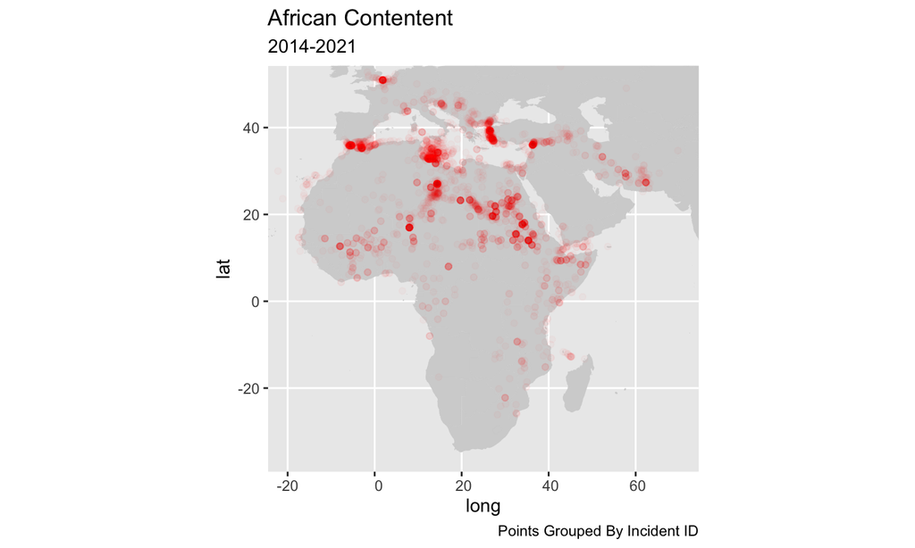

## Internal Factors

- “Islam and Arab political culture are not good explanations for the persistence of authoritarianism in the region” Haerpfer p(330)
- "There is a rather significant division between Islamist and liberals within civil society, which stops them from building coalitions that could challenge the authoritarian regimes. Haerpfer p(330)
- “Divisions between popular Islamist parties and generally discredited liberal-secular parties allow the regime to benefit from a lack of coherent opposition” Haerpfer p (334)

## The Sahara Desert

- Third Largest Desert in the world (3,600,000 Sq Miles), The largest Hot desert in the World, Coyotes(Not animals)

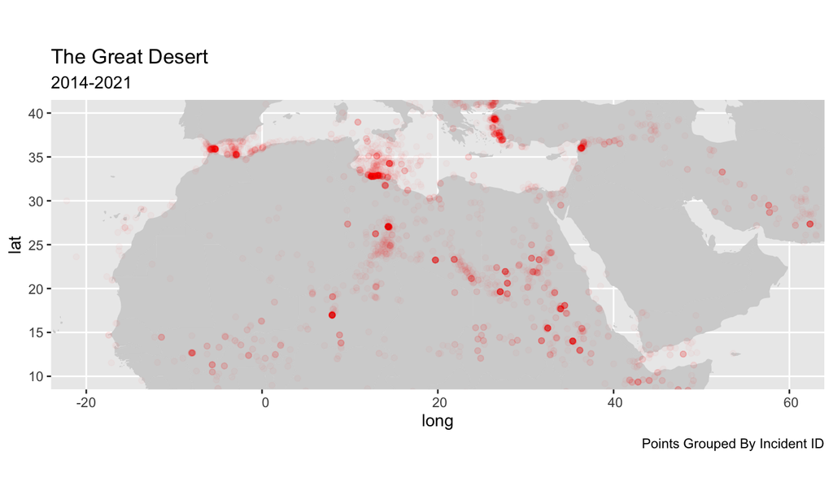

## Geographical Risks

- Red Sea.

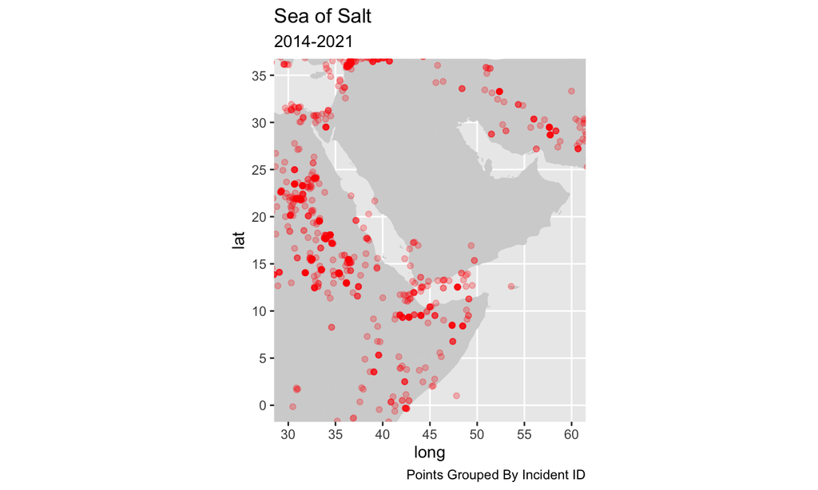

## Geographical Risks

- The Mediterranean Sea

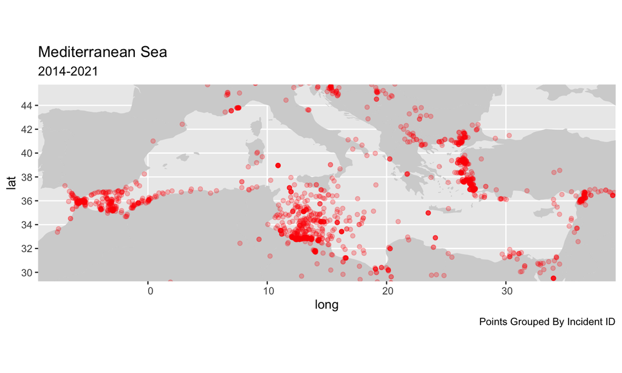

## Geographic Risks

- Boats Sinking
- Pirates

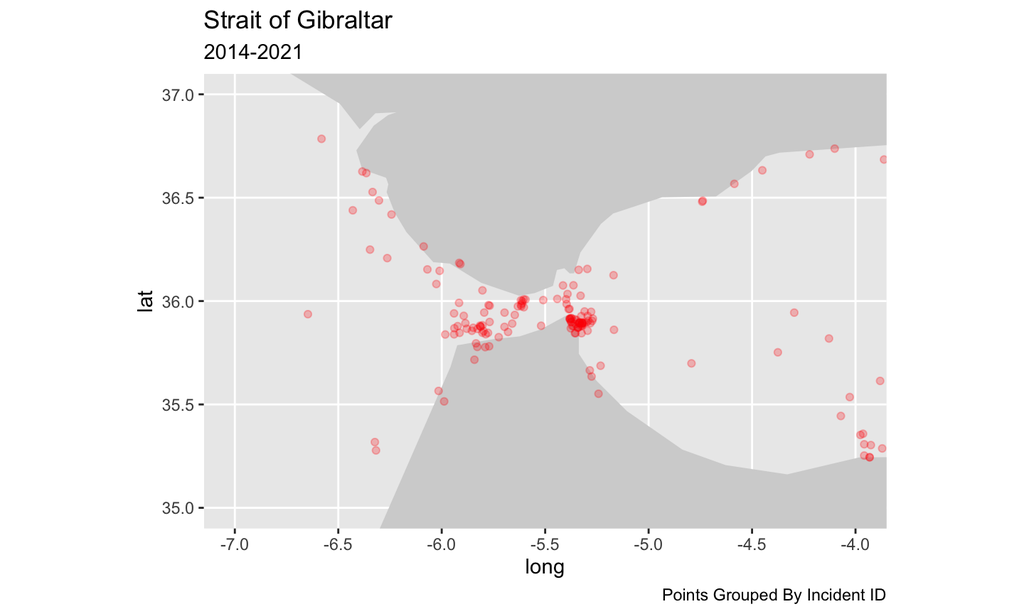

## Geographic Risks

- Same Risks different Location

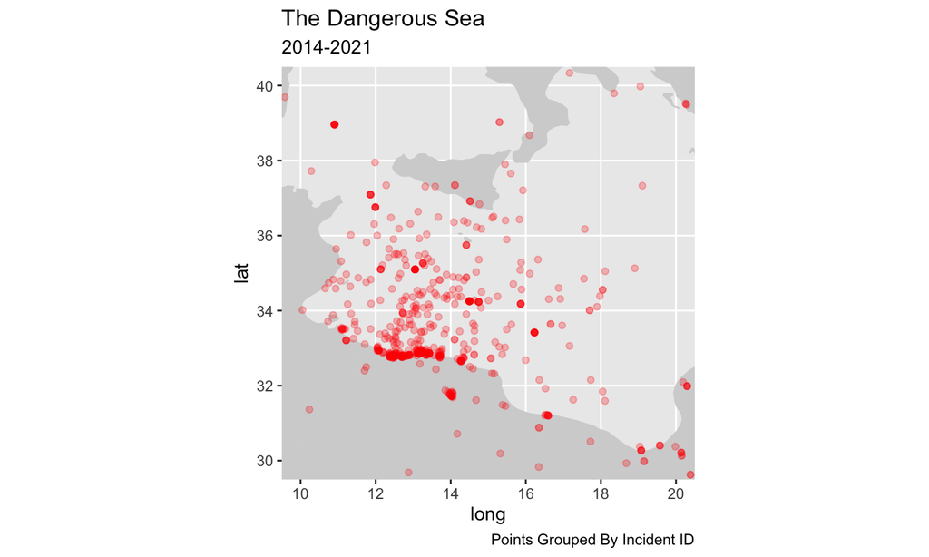

## Summary

- Geographical Factors: Crossing the Desert, Crossing the Sea
- Political Factors: Instability, Fear, Closing of Borders

Citation “Democratization” Christian W. Haerpfer Oxford University Press 2009